# Bike Share Case Study

Google Data Analytics Certificate Capstone Project

Lobna Allam

October 31, 2022

[figure not shown]

## Scenario

You are a junior data analyst working in the marketing analyst team at Cyclistic, a bike-share company in Chicago. The director of marketing believes the company’s future success depends on maximizing the number of annual memberships. Therefore, your team wants to understand how casual riders and annual members use Cyclistic bikes differently. From these insights, your team will design a new marketing strategy to convert casual riders into annual members. But first, Cyclistic executives must approve your recommendations, so they must be backed up with compelling data insights and professional data visualizations.

## Data Analysis Process

### 1) ASK

##### **Guiding Questions**

- How do annual members and casual riders use Cyclistic bikes differently?
- Why would casual riders buy Cyclistic annual memberships?
- How can Cyclistic use digital media to influence casual riders to become members?

##### **Consider key stakeholders**

- **Lily Moreno:** The director of marketing and your manager. Moreno is responsible for the development of campaigns and initiatives to promote the bike-share program. These may include email, social media, and other channels.
- **Cyclistic executive team:** The notoriously detail-oriented executive team will decide whether to approve the recommended marketing program.

##### **Identify the Business Task**

Both the Director of Marketing and finance analysts have concluded that annual members are more profitable in previous analysis. Therefore, the business task is to **present marketing strategies aimed at converting casual riders into annual members.**

### 2) PREPARE

##### **Download data and store it appropriately.**

- Bike Share data was retrieved from the [Kaggle Cyclistic Bike Share dataset](https://www.kaggle.com/datasets/evangower/cyclistic-bike-share). 12 CSV files were downloaded and saved locally prior to importing the files into RStudio.
- Chicago weather dataset is from the [National Centers for Environmental Information](https://www.ncei.noaa.gov/cdo-web/datasets/GHCND/locations/CITY:US170006/detail). The dataset was filtered to April 2021 - March 2022 and downloaded as a CSV file.

##### **Identify how it’s organized.**

- Bike Share: 12 months (April 2021 - March 2022) of Cyclistic Bike Share data is organized into 12 separate CSV (comma separated values) files. There are 15 columns per CSV with varying data types.
- Weather: A CSV file of the weather in Chicago from April 2021 - March 2022.

##### **Verify the data’s credibility.**

###### **Bike Share Data**

- The data is slightly outdated as the last dataset was collected 8 months ago.
- Due to COVID-19 lockdowns and provisions, the data may not be an accurate representation of how different members use the bike share service.
- The provided data has been made available by *Motivate International Inc.* under this [license](https://ride.divvybikes.com/data-license-agreement).
- This is a public dataset that respects data-privacy by removing riders’ personally identifiable information.

###### **Weather Data**

- Dataset includes data from 405 different stations within the city of Chicago and the period of this record is 100% coverage.
- The dataset is provided by a government entity for public use.
- The National Climatic Data Center offers the data for free and ensures that the content is available and accessible to all.

### 3) PROCESS

##### **Transform the data so you can work with it effectively.**

###### **Spreadsheets - Excel**

1. Added a column to each CSV file, *ride_length*, and formatted as HH:MM:SS. =(ended_at - started_at)
2. Created a column in all CSVs called *day_of_week*, and calculated the day of the week that each ride started using the “WEEKDAY” function.

###### **R - RStudio and Github for revision control**

3. Installed all necessary packages.

```r
install.packages("tidyverse", repos = "http://cran.us.r-project.org")
install.packages("lubridate", repos = "http://cran.us.r-project.org")
install.packages("ggplot2", repos = "http://cran.us.r-project.org")
install.packages("janitor", repos = "http://cran.us.r-project.org")
library(tidyverse)
library(lubridate)
library(ggplot2)
library(janitor)
```

4. Imported all datasets.

```r
april_21_trip_data <- read_csv("202104-divvy-tripdata.csv")
may_21_trip_data <- read_csv("202105-divvy-tripdata.csv")
june_21_trip_data <- read_csv("202106-divvy-tripdata.csv")
july_21_trip_data <- read_csv("202107-divvy-tripdata.csv")
aug_21_trip_data <- read_csv("202108-divvy-tripdata.csv")
sep_21_trip_data <- read_csv("202109-divvy-tripdata.csv")
oct_21_trip_data <- read_csv("202110-divvy-tripdata.csv")
nov_21_trip_data <- read_csv("202111-divvy-tripdata.csv")
dec_21_trip_data <- read_csv("202112-divvy-tripdata.csv")
jan_22_trip_data <- read_csv("202201-divvy-tripdata.csv")
feb_22_trip_data <- read_csv("202202-divvy-tripdata.csv")
march_22_trip_data <- read_csv("202203-divvy-tripdata.csv")
```

5. When importing CSV files, warning message about parsing issues arose. This was due to *docked_bike* rows having a ride_length of multiple days. These rows were referenced in Excel and the errors appeared in the corresponding rows in the CSV files. Because *docked_bike* rider_types were to be removed as part of the cleaning process, nothing was done during this step. problem() will be used after removing *docked_bike* rows to confirm that all errors have been removed.

```r
problems(april_21_trip_data)
```

```
## # A tibble: 37 × 5
##      row   col expected        actual                                      file
##    <int> <int> <chr>           <chr>                                       <chr>
##  1  9493    14 time in ISO8601 593:42:11                                   C:/U…
##  2 10049    14 time in ISO8601 796:16:42                                   C:/U…
##  3 10539    14 time in ISO8601 559:52:23                                   C:/U…
##  4 14825    14 time in ISO8601 142:30:43                                   C:/U…
##  5 22363    14 time in ISO8601 ##########################################… C:/U…
##  6 23514    14 time in ISO8601 126:01:19                                   C:/U…
##  7 24372    14 time in ISO8601 459:30:46                                   C:/U…
##  8 31846    14 time in ISO8601 ##########################################… C:/U…
##  9 44689    14 time in ISO8601 389:32:16                                   C:/U…
## 10 48955    14 time in ISO8601 184:03:43                                   C:/U…
## # … with 27 more rows
```

```r
#problems(may_21_trip_data)
#problems(june_21_trip_data)
#...
#problems(march_22_trip_data)
```

6. Wrangled data and combined into single file. Using Janitor package, compared columns in data frames for inconsistencies. None found.

```r
compare_df_cols(april_21_trip_data,
                may_21_trip_data,
                june_21_trip_data,
                july_21_trip_data,
                aug_21_trip_data,
                sep_21_trip_data,
                oct_21_trip_data,
                nov_21_trip_data,
                dec_21_trip_data,
                jan_22_trip_data,
                feb_22_trip_data,
                march_22_trip_data,
                return = "mismatch")
```

```
##  [1] column_name        april_21_trip_data may_21_trip_data   june_21_trip_data
##  [5] july_21_trip_data  aug_21_trip_data   sep_21_trip_data   oct_21_trip_data
##  [9] nov_21_trip_data   dec_21_trip_data   jan_22_trip_data   feb_22_trip_data
## [13] march_22_trip_data
## <0 rows> (or 0-length row.names)
```

7. Combined all data frames into one master data frame *total_trip_data*.

```r
total_trip_data <- rbind(april_21_trip_data,
                         may_21_trip_data,
                         june_21_trip_data,
                         july_21_trip_data,
                         aug_21_trip_data,
                         sep_21_trip_data,
                         oct_21_trip_data,
                         nov_21_trip_data,
                         dec_21_trip_data,
                         jan_22_trip_data,
                         feb_22_trip_data,
                         march_22_trip_data)
str(total_trip_data)
```

```
## spec_tbl_df [5,723,532 × 15] (S3: spec_tbl_df/tbl_df/tbl/data.frame)
##  $ ride_id           : chr [1:5723532] "6C992BD37A98A63F" "1E0145613A209000" "E498E15508A80BAD" "1887262AD101C604" ...
##  $ rideable_type     : chr [1:5723532] "classic_bike" "docked_bike" "docked_bike" "classic_bike" ...
##  $ started_at        : chr [1:5723532] "4/12/2021 18:25" "4/27/2021 17:27" "4/3/2021 12:42" "4/17/2021 9:17" ...
##  $ ended_at          : chr [1:5723532] "4/12/2021 18:56" "4/27/2021 18:31" "4/7/2021 11:40" "4/17/2021 9:42" ...
##  $ start_station_name: chr [1:5723532] "State St & Pearson St" "Dorchester Ave & 49th St" "Loomis Blvd & 84th St" "Honore St & Division St" ...
##  $ start_station_id  : chr [1:5723532] "TA1307000061" "KA1503000069" "20121" "TA1305000034" ...
##  $ end_station_name  : chr [1:5723532] "Southport Ave & Waveland Ave" "Dorchester Ave & 49th St" "Loomis Blvd & 84th St" "Southport Ave & Waveland Ave" ...
##  $ end_station_id    : chr [1:5723532] "13235" "KA1503000069" "20121" "13235" ...
##  $ start_lat         : num [1:5723532] 41.9 41.8 41.7 41.9 41.7 ...
##  $ start_lng         : num [1:5723532] -87.6 -87.6 -87.7 -87.7 -87.7 ...
##  $ end_lat           : num [1:5723532] 41.9 41.8 41.7 41.9 41.7 ...
##  $ end_lng           : num [1:5723532] -87.7 -87.6 -87.7 -87.7 -87.7 ...
##  $ member_casual     : chr [1:5723532] "member" "casual" "casual" "member" ...
##  $ ride_length       : 'hms' num [1:5723532] 00:31:19 01:04:18 94:57:39 00:25:06 ...
##   ..- attr(*, "units")= chr "secs"
##  $ day_of_week       : num [1:5723532] 2 3 7 7 7 1 7 3 2 7 ...
##  - attr(*, "spec")=
##   .. cols(
##   ..   ride_id = col_character(),
##   ..   rideable_type = col_character(),
##   ..   started_at = col_character(),
##   ..   ended_at = col_character(),
##   ..   start_station_name = col_character(),
##   ..   start_station_id = col_character(),
##   ..   end_station_name = col_character(),
##   ..   end_station_id = col_character(),
##   ..   start_lat = col_double(),
##   ..   start_lng = col_double(),
##   ..   end_lat = col_double(),
##   ..   end_lng = col_double(),
##   ..   member_casual = col_character(),
##   ..   ride_length = col_time(format = ""),
##   ..   day_of_week = col_double()
##   .. )
##  - attr(*, "problems")=<externalptr>
```

##### **Document the cleaning process.**

1. Confirmed that there are two types of members and three types of bikes.

Members: *casual*, *member*

Bikes: *classic_bike, electric_bike, docked_bike*

```r
rider_types <- total_trip_data %>%
  group_by(rideable_type, member_casual)

summarize(rider_types)
```

```
## # A tibble: 5 × 2
## # Groups:   rideable_type [3]
##   rideable_type member_casual
##   <chr>         <chr>
## 1 classic_bike  casual
## 2 classic_bike  member
## 3 docked_bike   casual
## 4 electric_bike casual
## 5 electric_bike member
```

2. *docked_bike* is when bikes were taken out of docks and checked for quality. This is irrelevant to the study, so removed from *total_trip_data*. Obtained total number of docked_bike to ensure that total removed is correct

```r
table(total_trip_data$rideable_type)
```

```
##
##  classic_bike   docked_bike electric_bike
##       3250691        303989       2168852
```

```r
total_trip_data <-
  total_trip_data[!grepl('docked_bike', total_trip_data$rideable_type),]

table(total_trip_data$rideable_type)
```

```
##
##  classic_bike electric_bike
##       3250691       2168852
```

3. Confirmed that there are no problems found in the data frame as expected in step e.

```r
problems(total_trip_data)
```

4. *start_station_name*, *end_station_name*, *start_station_id*, and *end_station_id* have over 700,000 null values. Columns were removed as the latitude and longitude can be used for ride paths. This also reduced the overall dataset size to be less than 1GB which is the limit on Tableau Public.

```r
#Finding total NA values in start_station_name and end_station_name
sum(is.na(total_trip_data$start_station_name))
```

```
## [1] 745376
```

```r
sum(is.na(total_trip_data$end_station_name))
```

```
## [1] 795782
```

```r
#Removed start_station_name and end_station_name columns
total_trip_data = subset(total_trip_data, select =
                           -c(start_station_name,end_station_name))
```

```r
#Finding total NA values in start_station_id and end_station_id
sum(is.na(total_trip_data$start_station_id))
```

```
## [1] 745373
```

```r
sum(is.na(total_trip_data$end_station_id))
```

```
## [1] 795782
```

```r
#Removed start_station_id and end_station_id columns
total_trip_data = subset(total_trip_data, select =
                           -c(start_station_id,end_station_id))
```

5. To confirm that there are no negative *ride_length* values, we must find the max and min. Originally in HMS format then converted to the nearest seconds.

```r
total_trip_data$ride_length <- seconds(hms(total_trip_data$ride_length))
#period_to_seconds() are used parse the time
total_trip_data$ride_length <- period_to_seconds(total_trip_data$ride_length)
sum(is.na(total_trip_data$ride_length))
```

```
## [1] 140
```

6. Remove all rows with NA *ride_length* values and check that all have been removed.

```r
total_trip_data <- drop_na(total_trip_data, ride_length)
sum(is.na(total_trip_data$ride_length))
```

```
## [1] 0
```

6. Confirm that there are no negative ride length values or obvious discrepancies.

```r
summary(total_trip_data$ride_length)
```

```
##    Min. 1st Qu.  Median    Mean 3rd Qu.    Max.
##       0     383     674    1086    1202   93596
```

##### **Aggregate your data so it’s useful and accessible.**

1. Aggregated the following data and formatted it into a data frame:
- Average *ride_length* by rider type.
- Median *ride_length* by rider type.
- Maximum *ride_length* by rider type.
- Minimum *ride_length* by rider type.
- Average *ride_length* per day of the week by rider type.

```r
agg_total_trip <- data.frame(
  "mean" =
    c(aggregate(total_trip_data$ride_length ~
                  total_trip_data$member_casual, FUN = mean)),
  "median" =
    c(aggregate(total_trip_data$ride_length ~
                  total_trip_data$member_casual, FUN = median)),
  "max" =
    c(aggregate(total_trip_data$ride_length ~
                  total_trip_data$member_casual, FUN = max)),
  "min" =
    c(aggregate(total_trip_data$ride_length ~
                  total_trip_data$member_casual, FUN = min)),
  "avg ride time per day" =
    c(aggregate(total_trip_data$ride_length ~
                  total_trip_data$member_casual
                + total_trip_data$day_of_week, FUN = mean))
)
```

2. Transposed aggregated data for easier readability

```r
#Transposed aggregated data for easier readability
agg_total_trip <- data.frame (t(agg_total_trip))
```

3. Prior to exporting the cleaned and transformed dataset, a quick visualization was created in R.

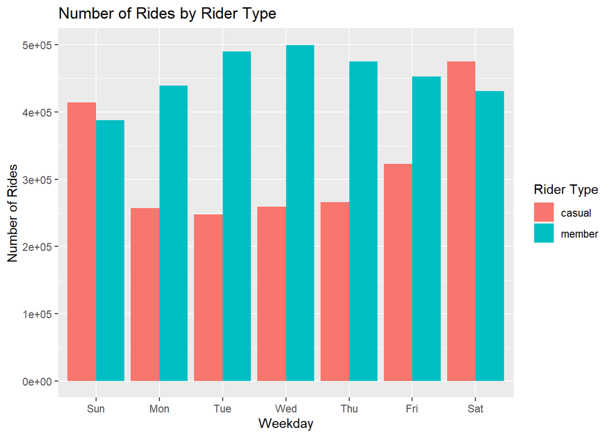

```r
#number of rides by rider type
total_trip_data %>%
  mutate(weekday = wday(day_of_week, label = TRUE)) %>%
  group_by(member_casual, weekday) %>%
  summarise(number_of_rides = n()
            ,average_duration = mean(ride_length)) %>%
  arrange(member_casual, weekday)  %>%
  ggplot(aes(x = weekday, y = number_of_rides, fill = member_casual)) +
  geom_col(position = "dodge") +
  labs(title = "Number of Rides by Rider Type", x = "Weekday",
       y = "Number of Rides", fill = "Rider Type")
```

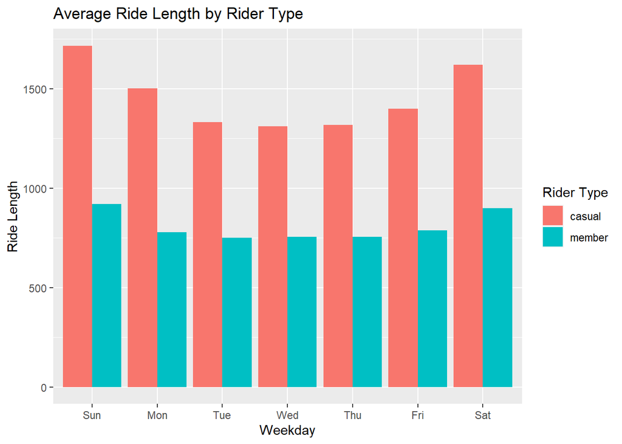

```r
#average duration
total_trip_data %>%
  mutate(weekday = wday(day_of_week, label = TRUE)) %>%
  group_by(member_casual, weekday) %>%
  summarise(number_of_rides = n()
            ,average_duration = mean(ride_length)) %>%
  arrange(member_casual, weekday)  %>%
  ggplot(aes(x = weekday, y = average_duration, fill = member_casual)) +
  geom_col(position = "dodge") +
  labs(title = "Average Ride Length by Rider Type", x = "Weekday",
       y = "Ride Length", fill = "Rider Type")
```

### 4 & 5) ANALYZE and SHARE

1. Dataset was exported to a CSV for use in Tableau.

```r
write.csv(total_trip_data,"C:\\Users\\...total_trip_data.csv", row.names = FALSE)
```

##### **Identify trends and relationships.**

###### **Ridership:**

Members had more trips than casual riders.

###### **Daily Ridership:**

Members had more rides during the week than casual riders, but casual riders had more rides during the weekend. This indicates that members use the service to commute to and from work while casual riders use this for leisure purposes.

###### **Average Ride Length:**

On average, casual riders’ trips were approximately 10 minutes longer than member trips.

###### **Average Ride Length Per Weekday:**

Casual riders always had longer trips per day than members. This did not change on the weekends.

###### **Monthly Ridership:**

Generally, members had more rides per month than casual riders. The increase in total trips during the summer months can be attributed to warmer temperatures.

###### **Bike Type:**

Classic bikes were used more often by both members and casual riders.

###### **Ridership Vs. Temperature:**

There appears to be a positive correlation between the number of rides and the average temperature for that day. A power regression shows that casual riders tend to ride more when the temperature is warmer.

###### **Trip Start Time:**

The two graphs compare the number of trips by rider type during the week on the weekend. The graph shows that both rider types start their trips at similar times on the weekend, but that members start their trips mostly at 8AM and 5PM on the weekdays. This indicates that members use the bike share service to commute to and from work.

[figure not shown]

### 6) ACT

##### **Next Steps**

###### My recommendations to the stakeholders:

- Offer reduced membership pricing in the winter months as there are less riders during that time.
- Offer a membership plan for 6 months instead of an annual membership. If most riders only use the service when it is warmer out, this may be an appealing subscription.
- Offer a membership service that is based on ride length or total minutes traveled. This may entice casual riders as they tend to have longer ride lengths on average.
- Launch social media ads for subscriptions in May as this is when people begin utilizing the bike share service.

##### **Additional Data**

###### Requests for additional data:

- The total number of electric and classic bike types available. This would show what type was preferred by the riders. The current data does not show how many are available.
- Membership ID’s would show how often the same rider uses the service.
- Membership ID’s would show us how often the same rider travels the same path.